# Versao_atual

## Raspagem de dados e análise exploratória para seleção de textos

**Autor: André Farinaccio Boldrin**

**E-mail: andre.boldrin@gmail.com**

**Website: https://afboldrin.github.io**

O trabalho consistiu no desenvolvimento de um robô para “download” de textos de domínio público, com o objetivo de auxiliar o usuário a selecionar bons textos para sua aprendizagem na Língua Estrangeira (Inglês). Através da consolidação de material proveniente do Projeto Gutenberg e proporcionando a visualização de características textuais e estatísticas que facilitem a escolha de textos para aprendizado.

```python
#!pip install lexicalrichness
#import lexicalrichness
#from lexicalrichness import LexicalRichness
```

# 0. Preparação do ambiente

## Instalando Bibliotecas

Seção para instalação de bibliotecaso

```python
# Instalação da biblioteca para processamento de linguagem natural
!pip install nltk

# Instalação da biblioteca para manipulação de dados
!pip install pandas

# Instalação da biblioteca para requisições HTTP
!pip install requests

# Instalação da biblioteca para geração de nuvem de palavras
!pip install wordcloud

# Instalação da biblioteca para visualização de dados
!pip install matplotlib
```

```
# Isto está formatado como código
```

## Importanto Bibliotecas

Seção para carregamento de bibliotecas

```python
import os
import string
import requests
from collections import Counter

import pandas as pd
import re

import nltk
from nltk.probability import FreqDist
from nltk import word_tokenize, pos_tag, ne_chunk
from nltk.corpus import stopwords
from nltk.corpus import PlaintextCorpusReader
from nltk.probability import FreqDist

# Downloads de recursos do NLTK
nltk.download([
    "stopwords",
    "punkt",
    "averaged_perceptron_tagger",
    "maxent_ne_chunker",
    "words",
])

import wordcloud
import matplotlib.pyplot as plt
import seaborn as sns
```

# Importando vocabulário

Seção para upload (opcional) de vocabulário de palavras a ser utilizado como vocabulário prévio.

```python
#código deixado de lado pois abaixo fiz uma melhoria com ajuda do chatgpt
import csv
from google.colab import files
#get_words_from_file --> palavras_do_arquivo
def obter_palavras_do_arquivo():
    file_upload = files.upload()
    file_name = list(file_upload.keys())[0]
    file_type = file_name.split('.')[-1]

    if file_type == 'txt':
        with open(file_name, 'r') as file:
            words = file.read().split()
    else:
        print('Unsupported file type. Please upload a CSV or TXT file.')
        return None

    return words
```

```python
import csv
from google.colab import files

def obter_palavras_do_arquivo():
    # Realize o upload do arquivo
    arquivo_upload = files.upload()

    # Obtenha o nome e o tipo do arquivo
    nome_arquivo = list(arquivo_upload.keys())[0]
    tipo_arquivo = nome_arquivo.split('.')[-1]

    try:
        # Verifique se o tipo de arquivo é suportado
        if tipo_arquivo == 'txt':
            with open(nome_arquivo, 'r') as arquivo:
                # Leia as palavras do arquivo de texto
                palavras = arquivo.read().split()
        else:
            print('Tipo de arquivo não suportado. Por favor, faça o upload de um arquivo CSV ou TXT.')
            return None

    except Exception as e:
        print(f'Erro ao ler o arquivo: {e}')
        return None

    return palavras
```

```python
vocabulario_previo = obter_palavras_do_arquivo()
```

[output not shown]

# 1. Scrapping de livros

## Catálogo Projeto Gutenberg

Mirrors podem ser encontrados em: https://www.gutenberg.org/MIRRORS.ALL

Primeiramente, vamos fazer download do catálogo do Projeto

```python
try:
    pg_catalogo = pd.read_csv("https://www.gutenberg.org/cache/epub/feeds/pg_catalog.csv")
except Exception as e:
    print(f'Erro ao ler o arquivo CSV: {e}')
```

```python
# Filtra o DataFrame para incluir apenas textos em inglês do catálogo do Projeto Gutenberg.
# A coluna 'Type' é filtrada para incluir apenas 'Text' e a coluna 'Language' para incluir apenas 'en' (inglês).
df_catalogo = pg_catalogo[(pg_catalogo['Type'] == 'Text') & (pg_catalogo['Language'] == 'en')]
df_catalogo[2800:2850].head()
```

|  | Text# | Type | Issued | Title | Language | Authors | Subjects | LoCC | Bookshelves |
| --- | --- | --- | --- | --- | --- | --- | --- | --- | --- |
| 2938 | 2978 | Text | 2004-12-12 | The Memoirs of Jacques Casanova de Seingalt, 1... | en | Casanova, Giacomo, 1725-1798; Machen, Arthur, ... | Casanova, Giacomo, 1725-1798; Europe -- Histor... | D | NaN |
| 2939 | 2979 | Text | 2004-12-12 | The Memoirs of Jacques Casanova de Seingalt, 1... | en | Casanova, Giacomo, 1725-1798; Machen, Arthur, ... | Casanova, Giacomo, 1725-1798; Europe -- Histor... | D | NaN |
| 2940 | 2980 | Text | 2004-12-12 | The Memoirs of Jacques Casanova de Seingalt, 1... | en | Casanova, Giacomo, 1725-1798; Machen, Arthur, ... | Casanova, Giacomo, 1725-1798; Europe -- Histor... | D | NaN |
| 2941 | 2981 | Text | 2004-11-11 | The Memoirs of Jacques Casanova de Seingalt, 1... | en | Casanova, Giacomo, 1725-1798; Machen, Arthur, ... | Casanova, Giacomo, 1725-1798; Europe -- Histor... | D | Germany; Banned Books from Anne Haight's list |
| 2942 | 2982 | Text | 2004-10-04 | Mark Twain: A Biography. Volume I, Part 1: 183... | en | Paine, Albert Bigelow, 1861-1937 | Twain, Mark, 1835-1910; Authors, American -- 1... | PS | Bestsellers, American, 1895-1923 |

```python
"""
for title in pg_catalogo["Title"]:
  if "The Declaration of Independence" in title:
    print(title)
    """
```

```
'\nfor title in pg_catalogo["Title"]:\n  if "The Declaration of Independence" in title:\n    print(title)\n    '
```

## Download de livros

Definindo função para download de um livro específico do catálogo de livros do Projeto Project Gutenberg (PG):

```python
# função será descartada devido a função melhor abaixo


def pg_livro_2(codigo_catalogo):

  """
  Função para download de um livro do Projeto Gutenberg.
      - codigo_catalogo: o código de identificação do livro no catálogo do Projeto Gutenberg
      - filename: nome do arquivo de texto salvo localmente
  """
  # Requisição HTTP para obter conteúdo textual

  url = f'https://www.gutenberg.org/cache/epub/{codigo_catalogo}/pg{codigo_catalogo}.txt'
  #text --> texto
  texto = requests.get(url).text

  # Salvando o conteúdo textual em um arquivo de texto

  filename = f'{codigo_catalogo}.txt'
  with open(filename, 'w', encoding='utf-8') as f:
      f.write(text)

  return filename
```

```python
"""
def get_ebook_link(book_number,n):
    if book_number in range(1,10):
      subdirectories = '0'
    else:
      subdirectories = '/'.join(str(book_number)[:-1])
    link = f'https://mirror2.sandyriver.net/pub/gutenberg/{subdirectories}/{book_number}/{book_number}.txt'
    link_2 = f'https://mirror2.sandyriver.net/pub/gutenberg/{subdirectories}/{book_number}/{book_number}-0.txt'
    link_3 = f'https://mirror2.sandyriver.net/pub/gutenberg/{subdirectories}/{book_number}/{book_number}-8.txt'
    lst = [link,link_2,link_3]
    return lst[n]

"""
```

```
"\ndef get_ebook_link(book_number,n):\n    if book_number in range(1,10):\n      subdirectories = '0'\n    else:\n      subdirectories = '/'.join(str(book_number)[:-1])\n    link = f'https://mirror2.sandyriver.net/pub/gutenberg/{subdirectories}/{book_number}/{book_number}.txt'\n    link_2 = f'https:…
```

```python
"""
def get_ebook_link(book_number, n):
    if 1 <= book_number <= 9:
        subdirectories = '0'
    else:
        subdirectories = '/'.join(str(book_number)[:-1])

    link = f'https://mirror2.sandyriver.net/pub/gutenberg/{subdirectories}/{book_number}/{book_number}.txt'
    link_2 = f'https://mirror2.sandyriver.net/pub/gutenberg/{subdirectories}/{book_number}/{book_number}-0.txt'
    link_3 = f'https://mirror2.sandyriver.net/pub/gutenberg/{subdirectories}/{book_number}/{book_number}-8.txt'

    lst = [link, link_2, link_3]
    return lst[n]

"""
```

```
"\ndef get_ebook_link(book_number, n):\n    if 1 <= book_number <= 9:\n        subdirectories = '0'\n    else:\n        subdirectories = '/'.join(str(book_number)[:-1])\n\n    link = f'https://mirror2.sandyriver.net/pub/gutenberg/{subdirectories}/{book_number}/{book_number}.txt'\n    link_2 = f'http…
```

```python
"""
def get_ebook_link(book_number, n):
    if 1 <= book_number <= 9:
        subdirectories = '0'
    else:
        subdirectories = '/'.join(str(book_number)[:-1])

    prefix = "https://mirrors.xmission.com/gutenberg"

    link = f'{prefix}/{subdirectories}/{book_number}/{book_number}.txt'
    link_2 = f'{prefix}/{subdirectories}/{book_number}/{book_number}-0.txt'
    link_3 = f'{prefix}/{subdirectories}/{book_number}/{book_number}-8.txt'

    lst = [link, link_2, link_3]
    return lst[n]
"""
```

```
'\ndef get_ebook_link(book_number, n):\n    if 1 <= book_number <= 9:\n        subdirectories = \'0\'\n    else:\n        subdirectories = \'/\'.join(str(book_number)[:-1])\n\n    prefix = "https://mirrors.xmission.com/gutenberg"\n\n    link = f\'{prefix}/{subdirectories}/{book_number}/{book_number}…
```

```python
def get_ebook_link(book_number, n):
    """
    Retorna uma lista de URLs para download de ebooks do Projeto Gutenberg com base no número do livro.

    Parâmetros:
    - book_number: Número do livro no Projeto Gutenberg.
    - n: Índice para escolher entre as URLs disponíveis (0, 1, ou 2).

    Retorna:
    Lista de URLs correspondentes.
    """
    subdirectories = '0' if 1 <= book_number <= 9 else '/'.join(str(book_number)[:-1])
    prefix = "https://mirrors.xmission.com/gutenberg"

    def generate_link(suffix):
        return f'{prefix}/{subdirectories}/{book_number}/{book_number}{suffix}.txt'

    lst = [generate_link(""), generate_link("-0"), generate_link("-8")]
    return lst[n]
```

```python
get_ebook_link(3,0)
```

```
'https://mirrors.xmission.com/gutenberg/0/3/3.txt'
```

```python
# melhorar código abaixo
def pg_livro(codigo_catalogo):
    """
    Função para download de um livro do Projeto Gutenberg.
      - codigo_catalogo: o código de identificação do livro no catálogo do Projeto Gutenberg
      - filename: nome do arquivo de texto salvo localmente
    """
    # Loop through the three possible URLs
    for i in range(3):
        try:
            url = get_ebook_link(codigo_catalogo, i)
            response = requests.get(url)
            print(url, response)

            # Check the status code of the response
            if response.status_code == 200:
                texto = response.text

                # Salvando o conteúdo textual em um arquivo de texto
                filename = f'/content/Livros_Selecionados/{codigo_catalogo}.txt'
                with open(filename, 'w', encoding='utf-8') as f:
                    f.write(texto)
                return filename
            else:
                # If the status code is not 200, try the next URL
                continue
        except requests.exceptions.RequestException:
            # If there is an error with this URL, try the next one
            continue

    # If none of the URLs worked, raise an exception
    raise Exception('Failed to download book text')
```

```python
def pg_livro(codigo_catalogo):
    """
    Função para download de um livro do Projeto Gutenberg.
      - codigo_catalogo: o código de identificação do livro no catálogo do Projeto Gutenberg
      - filename: nome do arquivo de texto salvo localmente
    """
    # Loop through the three possible URLs
    for i in range(3):
        try:
            url = get_ebook_link(codigo_catalogo, i)
            response = requests.get(url)
            print(f'Tentando URL: {url}, Resposta: {response}')

            # Verifica o código de status da resposta
            if response.status_code == 200:
                texto = response.text

                # Salva o conteúdo textual em um arquivo de texto
                filename = f'/content/Livros_Selecionados/{codigo_catalogo}.txt'
                with open(filename, 'w', encoding='utf-8') as file:
                    file.write(texto)
                return filename
            else:
                # Se o código de status não for 200, tenta a próxima URL
                continue
        except requests.exceptions.RequestException as e:
            # Se houver um erro com esta URL, tenta a próxima
            print(f'Erro ao tentar a URL: {url}, {e}')
            continue

    # Se nenhuma das URLs funcionar, gera uma exceção
    raise Exception('Falha ao baixar o texto do livro')
```

Em seguida, daremos início a etapa de pré-processamento de dados

# Lista de livros

Definição da função que vai permitir ao usuário escolher quais livros deseja avaliar

```python
# melhor linha de código abaixo
"""

def escolher_livros():
  x = input("Escolha um livro: ")
  if x.isdigit():
    x = int(x)

  if x in df_catalogo['Text#'].values:

    if x not in livros_escolhidos:
      livros_escolhidos.append(x)
    y = input("Deseja escolher mais algum? ")
    if y.lower() == "sim":
      escolher_livros()
    else:
      print(f"Certo, seus livros escolhidos são: {', '.join(map(str, livros_escolhidos))}")
  else:
    print("Este livro não está no catálogo de livros em inglês, escolha outro livro")
    escolher_livros()
"""
```

```
'\n\ndef escolher_livros():\n  x = input("Escolha um livro: ")\n  if x.isdigit():\n    x = int(x)\n\n  if x in df_catalogo[\'Text#\'].values:\n\n    if x not in livros_escolhidos:\n      livros_escolhidos.append(x)\n    y = input("Deseja escolher mais algum? ")\n    if y.lower() == "sim":\n      esc…
```

```python
def escolher_livros(df_catalogo, livros_escolhidos):
    try:
        escolha = input("Escolha um livro (Digite 'sair' para encerrar): ")
        if escolha.lower() == 'sair':
            print(f"Certo, seus livros escolhidos são: {', '.join(map(str, livros_escolhidos))}")
            return

        x = int(escolha)

        if x in df_catalogo['Text#'].values:
            if x not in livros_escolhidos:
                livros_escolhidos.append(x)
            else:
                print("Este livro já foi escolhido.")

            continuar = input("Deseja escolher mais algum? (sim/não): ")
            if continuar.lower() == "sim":
                escolher_livros(df_catalogo, livros_escolhidos)
            else:
                livros_escolhidos.sort()
                print(f"Certo, seus livros escolhidos são: {', '.join(map(str, livros_escolhidos))}")
        else:
            print("Este livro não está no catálogo de livros em inglês. Escolha outro livro.")
            escolher_livros(df_catalogo, livros_escolhidos)

    except ValueError:
        print("Por favor, digite um número válido.")
        escolher_livros(df_catalogo, livros_escolhidos)
```

Running the code

```python
# Uso da função
livros_escolhidos = []
escolher_livros(df_catalogo, livros_escolhidos)
```

```
Escolha um livro (Digite 'sair' para encerrar): 100
Deseja escolher mais algum? (sim/não): sim
Escolha um livro (Digite 'sair' para encerrar): 101
Deseja escolher mais algum? (sim/não): sim
Escolha um livro (Digite 'sair' para encerrar): 50
Este livro não está no catálogo de livros em inglês. Escolha outro livro.
Escolha um livro (Digite 'sair' para encerrar): nao
Por favor, digite um número válido.
Escolha um livro (Digite 'sair' para encerrar): sair
Certo, seus livros escolhidos são: 100, 101
```

```python
#falta ordenar
#livros_escolhidos = [101,201,301,401,501,601,701,801,901,1001]
livros_escolhidos
```

```
[100, 101]
```

```python
"""
folder_name = "Livros_Escolhidos"
parent_dir = "/content"

path = os.path.join(parent_dir, folder_name)
os.mkdir(path)
"""
```

```
'\nfolder_name = "Livros_Escolhidos"\nparent_dir = "/content"\n\npath = os.path.join(parent_dir, folder_name)\nos.mkdir(path)\n'
```

```python
"""
import shutil

# Define the directory path you want to delete
directory_to_delete = '/content/Livros_Selecionados'

# Use shutil.rmtree() to remove the directory and its contents
try:
    shutil.rmtree(directory_to_delete)
    print(f"Directory '{directory_to_delete}' and its contents have been successfully deleted.")
except OSError as e:
    print(f"Error deleting directory '{directory_to_delete}' and its contents: {e}")
"""
```

```
'\nimport shutil\n\n# Define the directory path you want to delete\ndirectory_to_delete = \'/content/Livros_Selecionados\'\n\n# Use shutil.rmtree() to remove the directory and its contents\ntry:\n    shutil.rmtree(directory_to_delete)\n    print(f"Directory \'{directory_to_delete}\' and its contents…
```

```python
import os
import shutil

# Caminho para o diretório temporário no Google Colab
temp_dir = '/content/'

# Verificar se o diretório existe
if os.path.exists(temp_dir):
    # Listar todos os arquivos no diretório
    files = os.listdir(temp_dir)

    # Excluir cada arquivo no diretório
    for file in files:
        file_path = os.path.join(temp_dir, file)
        try:
            if os.path.isfile(file_path):
                os.unlink(file_path)
            elif os.path.isdir(file_path):
                shutil.rmtree(file_path)
        except Exception as e:
            print(f"Erro ao excluir {file_path}: {e}")
else:
    print(f"O diretório {temp_dir} não existe.")
```

```python
import os

caminho_diretorio = '/content/Livros_Selecionados'

try:
    # Verifica se o diretório já existe
    if not os.path.exists(caminho_diretorio):
        # Cria o diretório se não existir
        os.mkdir(caminho_diretorio)
        print(f'Diretório "{caminho_diretorio}" criado com sucesso.')
    else:
        print(f'O diretório "{caminho_diretorio}" já existe.')

except OSError as e:
    print(f'Erro ao criar o diretório: {e}')
```

```
Diretório "/content/Livros_Selecionados" criado com sucesso.
```

```python
#código melhorado abaixo
estante = {}
for livro in livros_escolhidos:
  estante[livro]= pg_livro(livro)
```

```
Tentando URL: https://mirrors.xmission.com/gutenberg/1/0/100/100.txt, Resposta: <Response [404]>
Tentando URL: https://mirrors.xmission.com/gutenberg/1/0/100/100-0.txt, Resposta: <Response [200]>
Tentando URL: https://mirrors.xmission.com/gutenberg/1/0/101/101.txt, Resposta: <Response [200]>
```

```python
estante = {}

for livro in livros_escolhidos:
    try:
        # Verifica se o livro já está na estante
        if livro in estante:
            print(f'O livro {livro} já está na estante.')
            continue

        # Tenta baixar o livro e adicioná-lo à estante
        livro_downloaded = pg_livro(livro)
        estante[livro] = livro_downloaded
        print(f'O livro {livro} foi baixado e adicionado à estante.')

    except Exception as e:
        print(f'Erro ao processar o livro {livro}: {e}')
```

```
Tentando URL: https://mirrors.xmission.com/gutenberg/1/0/100/100.txt, Resposta: <Response [404]>
Tentando URL: https://mirrors.xmission.com/gutenberg/1/0/100/100-0.txt, Resposta: <Response [200]>
O livro 100 foi baixado e adicionado à estante.
Tentando URL: https://mirrors.xmission.com/gutenberg/1/0/101/101.txt, Resposta: <Response [200]>
O livro 101 foi baixado e adicionado à estante.
```

```python
# Criar DataFrame a partir do dicionário 'estante'
df_estante = pd.DataFrame.from_dict(estante, orient='index', columns=['Texto'])

# Exibir as primeiras linhas do DataFrame
df_estante.head()
```

|  | Texto |
| --- | --- |
| 100 | /content/Livros_Selecionados/100.txt |
| 101 | /content/Livros_Selecionados/101.txt |

# Análise textual

## Pré-processamento

Defini a função abaixo mas nao utilizei

```python
#biblioteca regular expressions,



def find_text_between_delimiters(fileid):

  """função para vamos retornar somente o conteúdo textual do livro, deixando de fora o metadados descritos pelo Projeto Guteberg."""

  with open(fileid, 'r', encoding='utf-8') as f:
      text = f.read()

  pattern = re.escape("START OF THE PROJECT GUTENBERG EBOOK") + r'(.*?)' + re.escape("END OF THE PROJECT GUTENBERG EBOOK")
  match = re.search(pattern, text, flags=re.DOTALL)

  if match:
      with open(fileid, 'w', encoding='utf-8') as f:
          f.write((match.group(1)))
  else:
    return None
```

```python
#corpus_root = pg_livro (5500)
#my_corpus = PlaintextCorpusReader(corpus_root, '.*\.txt')
```

```python
#y = [s.strip() for s in find_text_between_delimiters("308.txt").splitlines()]
```

```python
import os
current_dir = os.getcwd()
corpus_root = os.path.join(current_dir, 'Livros_Selecionados')
```

```python
#precisa checar por que eu precisar comentar a linha de baixo e incluir a de cima #todo
#corpus_root = 'Corpus/'

# Create a corpus object that reads in the text files from the directory
my_corpus = PlaintextCorpusReader(corpus_root, '.*\.txt')
```

```python
my_corpus.fileids()
```

```
['100.txt', '101.txt']
```

Divisão em parágrafos

```python
my_corpus.paras("100.txt")
```

```
[[['ï', '»¿***', 'START', 'OF', 'THE', 'PROJECT', 'GUTENBERG', 'EBOOK', 'THE', 'COMPLETE', 'WORKS', 'OF', 'WILLIAM', 'SHAKESPEARE', '***', 'ï', '»¿', 'The', 'Complete', 'Works', 'of', 'William', 'Shakespeare']], [['by', 'William', 'Shakespeare']], ...]
```

divisão em sentenças

```python
my_corpus.sents("100.txt")
```

```
[['ï', '»¿***', 'START', 'OF', 'THE', 'PROJECT', 'GUTENBERG', 'EBOOK', 'THE', 'COMPLETE', 'WORKS', 'OF', 'WILLIAM', 'SHAKESPEARE', '***', 'ï', '»¿', 'The', 'Complete', 'Works', 'of', 'William', 'Shakespeare'], ['by', 'William', 'Shakespeare'], ...]
```

Divisão em tokens

```python
words = my_corpus.words("100.txt")
my_corpus.words("100.txt")
```

```
['ï', '»¿***', 'START', 'OF', 'THE', 'PROJECT', ...]
```

```python
words
```

```
['ï', '»¿***', 'START', 'OF', 'THE', 'PROJECT', ...]
```

## Definindo métricas de características textuais

```python
class MyCorpusReader(PlaintextCorpusReader):
    def contar_palavras(self, fileid):
        """
        Conta o número de palavras em um arquivo no corpus.
        """
        palavras = self.words(fileid)
        return len(palavras)

    def TTR(self, fileid):
        """
        Calcula a Taxa Tipo-Token (TTR) para um arquivo no corpus.
        """
        palavras_no_arquivo = self.words(fileid)
        num_tipos = len(set(palavras_no_arquivo))
        num_tokens = len(palavras_no_arquivo)
        ttr = num_tipos / num_tokens
        return ttr

    def calcular_palavras_unicas(self, fileid, granularidade='palavras'):
        """
        Calcula o número de palavras únicas em um arquivo do corpus.
        """
        palavras_no_arquivo = self.words(fileid)
        palavras_unicas = set(palavras_no_arquivo)
        return len(palavras_unicas)

    def contar_palavras_novas(self, fileid, vocabulario_previo):
        """
        Calcula o número de palavras únicas em um arquivo do corpus que não estão no vocabulário prévio.
        """
        palavras_no_arquivo = self.words(fileid)
        palavras_unicas = set(palavras_no_arquivo)

        # Palavras únicas que não estão no vocabulário previamente obtido
        palavras_nao_presentes = palavras_unicas - set(vocabulario_previo)

        return len(palavras_nao_presentes)
```

```python
my_corpus = MyCorpusReader(corpus_root, '.*\.txt')
my_corpus.contar_palavras("100.txt")
```

```
1264706
```

```python
"""Obtém todos os fileids do corpus
fileids = my_corpus.fileids()

# Loop pelos fileids e calcular métricas para cada arquivo
for file_id in fileids:
    contagem_palavras = my_corpus.contar_palavras(file_id)
    ttr_do_arquivo = my_corpus.TTR(file_id)
    contagem_palavras_unicas = my_corpus.calcular_palavras_unicas(file_id)
    palavras_unicas_nao_presentes = my_corpus.contar_palavras_unicas_nao_presentes(file_id, vocabulario_previo)


    # Imprime ou armazena as métricas como desejar
    print(f'Métricas para o arquivo {file_id}:')
    print(f'Contagem de palavras: {contagem_palavras}')
    print(f'TTR do arquivo: {ttr_do_arquivo}')
    print(f'Contagem de palavras únicas: {contagem_palavras_unicas}')
    print('\n')"""
```

```
"Obtém todos os fileids do corpus\nfileids = my_corpus.fileids()\n\n# Loop pelos fileids e calcular métricas para cada arquivo\nfor file_id in fileids:\n    contagem_palavras = my_corpus.contar_palavras(file_id)\n    ttr_do_arquivo = my_corpus.TTR(file_id)\n    contagem_palavras_unicas = my_corpus.c…
```

```python
import pandas as pd

# Dicionário para armazenar métricas
metricas_dict = {'FileID': [], 'ContagemPalavras': [], 'TTR': [], 'PalavrasUnicas': [],'PalavrasNovas': [] }

# Loop pelos fileids e calcular métricas para cada arquivo
for file_id in fileids:
    # Armazena as métricas diretamente no dicionário
    metricas_dict['FileID'].append(file_id)
    metricas_dict['ContagemPalavras'].append(my_corpus.contar_palavras(file_id))
    metricas_dict['TTR'].append(my_corpus.TTR(file_id))
    metricas_dict['PalavrasUnicas'].append(my_corpus.calcular_palavras_unicas(file_id))
    metricas_dict['PalavrasNovas'].append(my_corpus.contar_palavras_novas(file_id, vocabulario_previo))

# Cria um DataFrame a partir do dicionário
df_metricas = pd.DataFrame(metricas_dict)

# Exibe o DataFrame
print(df_metricas)
```

```
    FileID  ContagemPalavras       TTR  PalavrasUnicas  PalavrasNovas
0  100.txt           1264706  0.027534           34822          34226
1  101.txt            131722  0.103088           13579          12921
```

```python
df_metricas
```

|  | FileID | ContagemPalavras | TTR | PalavrasUnicas | PalavrasNovas |
| --- | --- | --- | --- | --- | --- |
| 0 | 100.txt | 1264706 | 0.027534 | 34822 | 34226 |
| 1 | 101.txt | 131722 | 0.103088 | 13579 | 12921 |

```python
class MyCorpusReader(PlaintextCorpusReader):

    def count_words(self, fileid):
        """
        Count the number of words in a file in the corpus.
        """
        words = self.words(fileid)
        return len(words)
```

```python
def TTR(words):

  num_types = len(set(words))
  num_tokens = len(words)

  # Calculate TTR
  ttr = num_types / num_tokens
  return ttr
```

```python
def calculate_ttr(data, granularity='words'):
    """
    Calculate Type-Token Ratio (TTR) based on the chosen granularity.

    Parameters:
    - data: List of words, sentences, or paragraphs.
    - granularity: Granularity for TTR calculation ('words', 'sentences', 'paras').
    """

    if granularity == 'words':
        pass  # No additional processing needed for words
    elif granularity == 'sentences':
        # Flatten the list of sentences to get a list of words
        data = [word for sentence in data for word in sentence]
    elif granularity == 'paras':
        # Flatten the list of paragraphs to get a list of sentences
        data = [sentence for paragraph in data for sentence in paragraph]
        # Flatten the list of sentences to get a list of words
        data = [word for sentence in data for word in sentence]
    else:
        raise ValueError("Invalid granularity. Choose 'words', 'sentences', or 'paras'.")

    # Calculate the number of unique words (types) and the total number of words (tokens)
    num_types = len(set(data))
    num_tokens = len(data)

    # Calculate TTR
    ttr = num_types / num_tokens

    return ttr
```

```python
calculate_ttr(my_corpus.paras("100.txt"),'paras')
```

```
0.02753204692308422
```

```python
def calculate_unique_words(data, granularity='words'):
    """
    Calculate the number of unique words based on the chosen granularity.

    Parameters:
    - data: List of words, sentences, or paragraphs.
    - granularity: Granularity for calculation ('words', 'sentences', 'paras').

    Returns:
    - The number of unique words (types).
    """

    if granularity == 'words':
        unique_words = set(data)
    elif granularity == 'sentences':
        # Flatten the list of sentences to get a list of words
        words = [word for sentence in data for word in sentence]
        unique_words = set(words)
    elif granularity == 'paras':
        # Flatten the list of paragraphs to get a list of sentences
        sentences = [sentence for paragraph in data for sentence in paragraph]
        # Flatten the list of sentences to get a list of words
        words = [word for sentence in sentences for word in sentence]
        unique_words = set(words)
    else:
        raise ValueError("Invalid granularity. Choose 'words', 'sentences', or 'paras'.")

    return len(unique_words)
```

```python
calculate_unique_words(my_corpus.paras("100.txt"),'paras')
```

```
34820
```

```python
def calculate_calculate_total_words(data, granularity='words'):
    """
    Calculate the number of unique words based on the chosen granularity.

    Parameters:
    - data: List of words, sentences, or paragraphs.
    - granularity: Granularity for calculation ('words', 'sentences', 'paras').

    Returns:
    - The number of unique words (types).
    """

    if granularity == 'words':
        total_words = len(data)
    elif granularity == 'sentences':
        # Flatten the list of sentences to get a list of words
        words = [word for sentence in data for word in sentence]
        total_words = len(words)
    elif granularity == 'paras':
        # Flatten the list of paragraphs to get a list of sentences
        sentences = [sentence for paragraph in data for sentence in paragraph]
        # Flatten the list of sentences to get a list of words
        words = [word for sentence in sentences for word in sentence]
        total_words = len(words)
    else:
        raise ValueError("Invalid granularity. Choose 'words', 'sentences', or 'paras'.")

    return total_words
```

```python
#calculate_total_words(my_corpus.paras("100.txt"),'paras')
```

```python
#my_corpus.raw("100.txt")
```

Tags

```python
nltk.pos_tag(words)
```

[output not shown]

[output cut: 946 more lines]

```
 ('breed', 'VB'),
 ('another', 'DT'),
 ('thee', 'NN'),
 (',', ','),
 ('Or', 'CC'),
 ('ten', 'VB'),
 ('times', 'NNS'),
 ('happier', 'JJR'),
 ('be', 'VB'),
 ('it', 'PRP'),
 ('ten', 'VB'),
 ('for', 'IN'),
 ('one', 'CD'),
 (',', ','),
 ...]
```

Definindo funções a serem utilizadas para retornar características textuais

```python
nltk.FreqDist(my_corpus.words("100.txt")).most_common(15)
```

```
[(',', 94454),
 ('.', 90357),
 ('\x80\x99', 26261),
 ('the', 25571),
 ('I', 21803),
 ('and', 20110),
 ('to', 17241),
 ('of', 17177),
 ('a', 13893),
 (';', 12882),
 ('you', 12641),
 ('my', 11410),
 ('?', 11337),
 ('in', 11228),
 ('is', 8809)]
```

```python
nltk.FreqDist(my_corpus.words("100.txt"))["what"]
```

```
2288
```

```python
len(my_corpus.words("100.txt"))
```

```
1264706
```

```python
len(set(word.lower() for word in my_corpus.words("100.txt")))
```

```
28585
```

Tokenização do corpus

```python
df['Tokens'] = df['Texto'].apply(nltk.word_tokenize)
```

[output not shown]

- Desconsiderando pontuação
- Criando uma lista com tokens únicos
- Contando tokens únicos
- Categorizando tokens

```python
"""
df ['Tokens_limpos'] = df["Tokens"].apply(lambda x: [word for word in x if word not in list(string.punctuation)])
df ["Tokens_lower"] = df['Tokens_limpos'].apply(lambda x:[word.lower() for word in x])
df ['Tokens_unicos'] = df['Tokens_limpos'].apply(lambda x: sorted(list(set(x))))
df ['Qde_Tokens_unicos'] = df['Tokens_unicos'].apply(lambda x: len(x))
df ["Categorias"] = df['Tokens_unicos'].apply(lambda x: nltk.pos_tag(x))
#falta lower os tokens antes de fazer coisas
"""
```

```
'\ndf [\'Tokens_limpos\'] = df["Tokens"].apply(lambda x: [word for word in x if word not in list(string.punctuation)])\ndf ["Tokens_lower"] = df[\'Tokens_limpos\'].apply(lambda x:[word.lower() for word in x])\ndf [\'Tokens_unicos\'] = df[\'Tokens_limpos\'].apply(lambda x: sorted(list(set(x))))\ndf […
```

Calculando Type-Token Ratio (TTR) (Diversidade Lexica)

```python
#df['TTR'] = df.apply(lambda x: len(x['Tokens_unicos'])/len(x['Tokens_limpos'])*100, axis=1)
```

Filtrando palavras de conteúdo

```python
#df["Tokens_conteudo"] = df["Categorias"].apply(lambda x: [word for word, pos in x if pos[:2] in ['NN', 'JJ', 'VB', 'RB']])
```

Calculando densidade lexical

```python
#densidade_lexical = len(content_words) / len(tokens)*100
#df['Dens_lexical'] = df.apply(lambda x: len(x["Tokens_conteudo"])/len(x['Tokens_limpos'])*100, axis=1)
```

# Problema de Cobertura de Conjuntos (PCC)- Greedy Algorithm Approach

Input: livros (lista paragrafos, lista de sentenças, lista de palavras); vocabulario_previo (lista de palavras)

Output: livros em ordem dos que tem mais palavras desconhecidas

```python
vocabulario_previo = ['the', 'be', 'to', 'of', 'and', 'a', 'in', 'that', 'have', 'I', 'it', 'for', 'not', 'on', 'with', 'he', 'as', 'you', 'do', 'at', 'this', 'but', 'his', 'by', 'from', 'they', 'we', 'say', 'her', 'she']
texto1 = "The sun shone brightly in the clear blue sky as the birds sang their cheerful melodies. A gentle breeze blew through the trees, rustling the leaves and filling the air with the sweet scent of flowers. It was a perfect day to spend outdoors, basking in the warmth of the sun and enjoying the beauty of nature."
texto2 = "The city was bustling with activity as people hurried to and fro, going about their daily business. Cars honked their horns and sirens blared in the distance, creating a constant background noise that never ceased. Despite the chaos, there was a sense of excitement in the air, as if anything was possible in this vibrant and dynamic city."
texto3 = "The old man sat alone in his small cabin, staring out at the desolate landscape that stretched out before him. The wind howled outside, causing the shutters to rattle and the fire to flicker. He had been living like this for years, isolated and alone, with only his memories to keep him company. But despite the loneliness, he knew that he would never leave this place, for it was his home."
texto4 = "The music swelled to a crescendo as the dancers moved in perfect synchronization, their bodies flowing together as one. The audience was captivated, their eyes fixed on the stage as the performers continued to move with grace and precision. It was a magical moment, a fleeting glimpse into a world where anything was possible and dreams could come true."
textos = [texto1,texto2,texto3,texto4]
```

```python
def greedy(fileids, vocab_previo):
    vocab_novo_count = {}
    for fileid in fileids:
        vocab_novo_count[fileid] = 0
    lowered_vocab = set(word.lower() for word in vocab_previo)
    for fileid in fileids:
        palavras_unicas = set(word.lower() for word in my_corpus.words(fileid))
        total_words = len(my_corpus.words(fileid))

        for word in palavras_unicas:
            if word not in lowered_vocab:
                vocab_novo_count[fileid] += 1
    ordered_books = dict(sorted(vocab_novo_count.items(), key=lambda item: item[1], reverse=True))
    return ordered_books
```

```python
fileids = my_corpus.fileids()
fileids
```

```
['100.txt', '101.txt']
```

```python
dic = greedy(fileids, vocabulario_previo)
```

```python
for key,value in dic.items():
  print(f"O livro {key} possui {value} palavras não aprendidas, o que representa {round(100*value/len(my_corpus.words(key)),2)} % do livro")
```

```
O livro 100.txt possui 28555 palavras não aprendidas, o que representa 2.26 % do livro
O livro 101.txt possui 11585 palavras não aprendidas, o que representa 8.8 % do livro
```

```python
count = []
for texto in textos:
  count.append(len(set(vocabulario_previo).symmetric_difference(texto)))
```

```python
def set_cover(sets, elements):
  coverage_count = []
  for s in sets:
    coverage = len(s & elements)
    if coverage > max_coverage:
        max_set = s
        max_coverage = coverage
```

# Visualização

Exemplo função word cloud

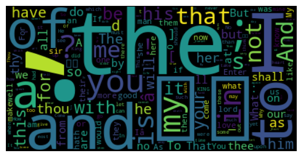

```python
# Define the books and their contents
books = {
    'Book 1': words,
    'Book 2': ['She', 'sells', 'seashells', 'by', 'the', 'seashore.'],
    'Book 3': ['How', 'much', 'wood', 'would', 'a', 'woodchuck', 'chuck', 'if', 'a', 'woodchuck', 'could', 'chuck', 'wood?'],
    'Book 4': ['André', 'André', 'test', 'water']
}

# Define a function to generate a word cloud for a specific book
def generate_wordcloud(book_dict, book_title):
    # Create a Counter object to count the occurrence of each word
    word_counter = Counter(book_dict[book_title])

    # Generate a word cloud using the Counter object
    wc = wordcloud.WordCloud()
    wc.generate_from_frequencies(word_counter)

    # Display the word cloud using matplotlib
    plt.imshow(wc, interpolation='bilinear')
    plt.axis('off')
    plt.show()

# Call the function with the books dictionary and the desired book title as input
generate_wordcloud(books, 'Book 1')
```

```python
def plot_word_counts(books, vocabulary):
    word_counts = []
    for book_title, book_words in books.items():
        unique_words = set(book_words) - set(vocabulary)
        word_counts.append({'book': book_title, 'count': len(unique_words)})
    word_counts.sort(key=lambda x: x['count'], reverse=True)
    df = pd.DataFrame(word_counts)
    sns.set_style("whitegrid")
    plt.figure(figsize=(9,1))
    ax = sns.barplot(x='count', y='book', data=df, palette="Blues_d")
    ax.set(xticks=[], xlim=(0, max(df['count']) + 1))
    ax.set_xlabel('Unique Word Count', fontsize=12)
    ax.set_ylabel('Book''s ID', fontsize=12)
    for i, v in enumerate(df['count']):
        ax.text(v + 0.2, i, str(v), color='black', fontsize=10, va='center')
    plt.show()
```

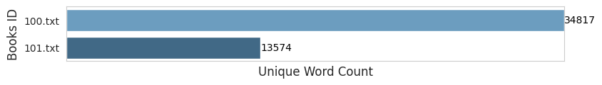

```python
books = {
}

for i in my_corpus.fileids():
  books[i]=my_corpus.words(i)

vocabulary = ['the', 'a', 'an', 'of', 'if']  # list of words to exclude

plot_word_counts(books, vocabulary=vocabulary)
```